### Characterizing participant observations

This is an analysis of the study_observations.xls file that lives in RWJF/Behavioral Phenotyping/Evalutation

```
##
##  HTML SHINY
##    79    79
```

Interestingly, participants generated the same number of observations using the HTML-based and interactive tools (79).

We can further assess the nature of observations generated by participants:

```
##
##         BG Nutrition
##   HTML  38        39
##   SHINY 51        27
```

```
##
##  Pearson's Chi-squared test with Yates' continuity correction
##
## data:  obs$tool and obs$type
## X-squared = 3.445, df = 1, p-value = 0.06344
```

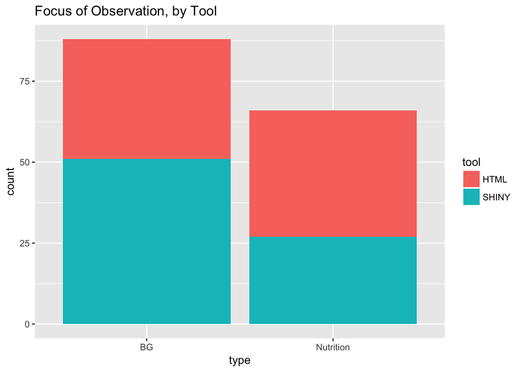

This plot demonstrates that the interactive tool elicited more observations focused on changes in blood glucose, while the HTML-based representation facilitated sense-making of nutritional content. This difference is approaching statistical significance (p = 0.063).

We labeled each observation with more detail:

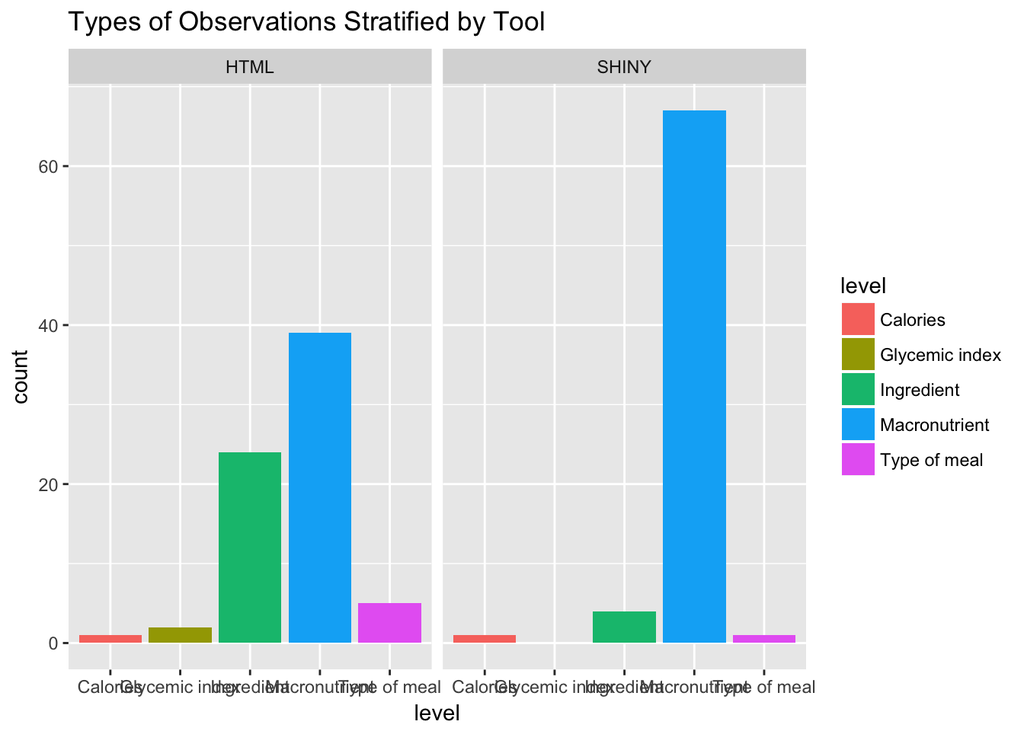

```
##
##         Calories Glycemic index Ingredient Macronutrient Type of meal
##   HTML         1              2         24            39            5
##   SHINY        1              0          4            67            1
```

It is clear that participants were more likely to reason about specific ingredients using the HTML representation. In contrast, the visual analytics tool facilitated reasoning using the macronutrient content of meals.

### Assessment of statement accuracy

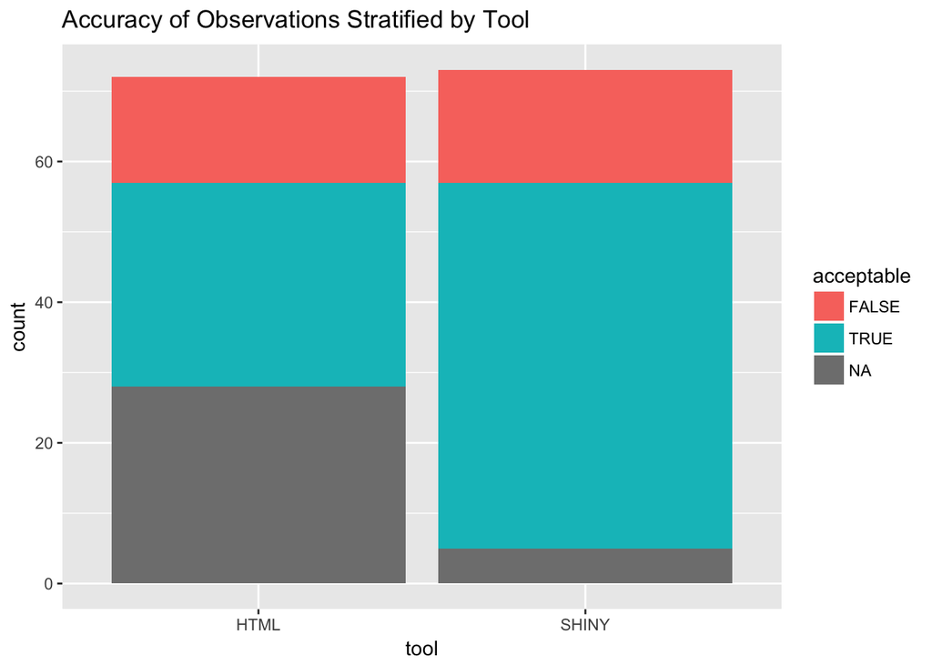

```r
ggplot(obs_rm[!is.na(obs_rm$tool) & !is.na(obs_rm$type), ],
       aes(x = tool, fill = acceptable))+
  geom_histogram(stat="count")+
  ggtitle("Accuracy of Observations Stratified by Tool")
```

```r
table(obs_rm$tool, obs_rm$acceptable)
```

```
##
##         FALSE TRUE
##   HTML     15   29
##   SHINY    16   52
```

We quanitatively assessed whether observations were supported by the data. This required translation of dietitian’s written statements into conditional statements.

The plot above demonstrates that the overall accuracy of observations was higher using the interactive tool (76.4% vs. 65.9%)

```r
chisq.test(obs_rm$acceptable, obs_rm$tool)
```

```
##
##  Pearson's Chi-squared test with Yates' continuity correction
##
## data:  obs_rm$acceptable and obs_rm$tool
## X-squared = 1.0078, df = 1, p-value = 0.3154
```

Unfortunately, there were too little data for this difference to be statistically significant.

#### Observations regarding glycemic response

```r
BG <- obs_rm %>% filter(type == 'BG')
chisq.test(BG$acceptable, BG$tool)
```

```
##
##  Pearson's Chi-squared test with Yates' continuity correction
##
## data:  BG$acceptable and BG$tool
## X-squared = 0.055116, df = 1, p-value = 0.8144
```

```r
table(BG$acceptable, BG$tool)
```

```
##
##         HTML SHINY
##   FALSE    5    12
##   TRUE    20    35
```

Statements generated with the interactive tool regarding blood glucose changes *were not* more accurate than those generated with the HTML representation. (p = 0.81)

**Discussion:**

We knew that one of the limitations of the study was my failure to transform the macronutrient & glycemic data against a reference standard (eg. acceptable BG change is <115 or 20-35g carbohydrates/meal). This could certainly explain the lack of improvement in observations related specifically to glycemic response.

SHINY may have improved understanding of general trends in blood glucose but not associations of BG change and macronutrients/mealtimes. In contrast, no observations generated using HTML contained an inference such as ‘dinner: BG change no peaks, they are average’

#### Observations regarding nutrition & macronutrient composition

```r
nutrition <- obs_rm %>% filter(type == 'Nutrition')
chisq.test(nutrition$acceptable, nutrition$tool)
```

```
##
##  Pearson's Chi-squared test with Yates' continuity correction
##
## data:  nutrition$acceptable and nutrition$tool
## X-squared = 3.5793, df = 1, p-value = 0.0585
```

```r
table(nutrition$acceptable, nutrition$tool)
```

```
##
##         HTML SHINY
##   FALSE   10     4
##   TRUE     9    17
```

## Comparing the quality of observations further

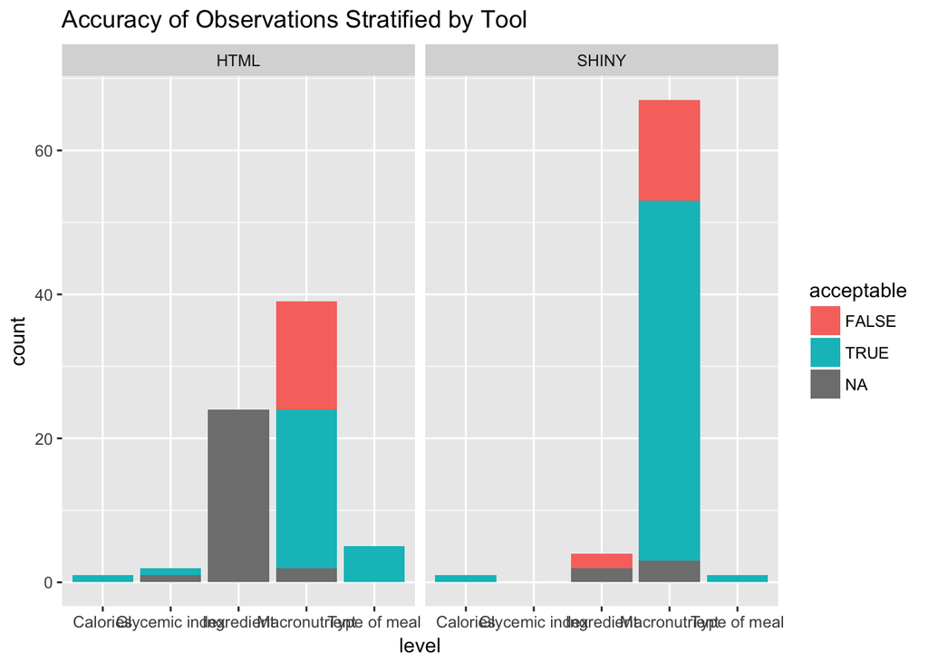

```r
ggplot(obs_rm[!is.na(obs_rm$tool) & !is.na(obs_rm$level), ],
       aes(x = level, fill = acceptable))+
  geom_histogram(stat="count")+
  facet_grid(~tool)+
  ggtitle("Accuracy of Observations Stratified by Tool")
```

Again we can see that the majority of observations were related to macronutrients and/or blood glucose change. Most of the observations that we did not judge as acceptable/unacceptable related to ingredients of a specific meal / mealtypes (break, lunch, or dinner).